# PCOS Survey

## Context

A survey was carried out to know how much is known about PCOS among Nigerian women as well as its latent and potential impacts on the population.

## Details on the Dataset:

The data contains responses to survey questions. The columns were renamed to make them easier to analyse with code. Here is the list of columns in the engineered dataset:

- `DATE`: Datetime- the date and time that the respondent filled the survey, automatically generated by JotForms, the survey service provider.
- `ID`: The respondent ID filled in during the data engineering process.
- `AGE`: The age group within which the respondent falls, given as intervals 18-24, 25-34,35-44 and 45-54
- `STATE_ORIGIN`: The respondent's state of origin. We had respondents respresenting every state in Nigeria including the FCT.
- `STATE_RES` : The respondent's state of residence. At least one from overy state in Nigeria and some from outside the country.
- `EDUCATION`: The level of education attained by the respondent. VAlues are None, Primary, Secondary and Tertiary
- `HEALTH_INSURANCE`: Yes or No responses to whether or not the respondent has health insurance.
- `MONTHLY_INCOME`: Income brackets of 0-30,000, 31,000-75,000, 76,000-150,000, 151,000-300,000 and 301,000 and above.
- `EXERCISE` : How regularly the respondent exercises. Responses are 4 or more times a week, at least once a week/month/year/None.
- `ALCOHOL` : Whether or not the resondent drinks alcohol. Yes/No
- `SMOKING` : Whether or not the respondent smokes. Yes/No
- `INSOMNIA` : Whether or not the respondent suffers with insomnia. Yes/No
- `MENSES` : Whether or the respondent mentruates. Yes/No
- `REGULAR_CYCLE` : Whether or not the respondents have a regular menstrual cycle. Yes/No
- `CRAMPS` : Whether the respondents suffer cramps and when. Yes/No, yes, during my period, Yes, off my period, Yes, during and off my period.
- `HAVE_KIDS` : Whether or not the respondents have children. Yes/No
- `WANT_KIDS` : Whether or not the respondent intends to have children. Yes/No
- `DIABETES` : Whether the respondent or family member has/had diabetes. Yes/No
- `HBP` : Whether the respondent or family has/has high blood pressure. Yes/No
- `PCOS_HI` : What, if anything, the respondent knows about PCOS and/or hormonal imbalance. Responses are: I have a fair amount of knowledge/Ihave heard about it but that's all/ Nothing at all/ I have extensive knowledge.
- `TREATMENT` : Whether the respondent has ever sought diagnoses/treatment for PCOS. Yes/No
- `TREATMENT_FACILITY` : What kind of treatment facility the respondent visited. Conventional(hospital/clinic), Alternative treatment or Both.
- `MEDICINE_PURCHASE` : Where the respondent bought medication. Walk-in Pharmacy/online,Nigerian or International?
- `AFFORDABILITY` : Rank affordability from 1-5 where 5 is most affordable.
- `SYMPTOMS_1` : First list of symptoms related to PCOS. These include: Fatigue, Acne/Pimples, Mood changes/Depression, Excessive body hair growth, Weight changes and trouble losing weight, Irregular, prolonged, or missed periods, Low sex drive, Hair loss/thinning hair, Pelvic pain, Skin darkening/Hyperpigmentation, Difficulty conceiving, NONE of the above. Respondents could choose any number of symptoms they identify.
- `SYMPTOMS_2` : Second list of symptoms related to PCOS. These are: Anxiety, Mood Swings, Unexplained feeling of sadness, Feelings of hopelessness, Difficulty with concentration, Loss of interest/pleasure in activities, Easily upset/irritable, Excessive crying, NONE of the above Respondents could choose any number of symptoms they identify.
- `S1_GRP` : Responses batched by number of symptoms from `SYMPTOMS_1`.
- `S2_GRP` : Responses batched by number of symptoms from `SYMPTOMS_2`.

### Loading Libraries

```python
# this will help in making the Python code more structured automatically (good coding practice)
%load_ext nb_black

#Mute warnings for a neater notebook
import warnings

warnings.filterwarnings("ignore")
from statsmodels.tools.sm_exceptions import ConvergenceWarning

warnings.simplefilter("ignore", ConvergenceWarning)

# Libraries to help with reading and manipulating data

import pandas as pd
import numpy as np


# libaries to help with data visualization
import matplotlib.pyplot as plt
import seaborn as sns

#Import Folium for generating maps
import folium
from folium import Choropleth, Circle, Marker
from folium.plugins import HeatMap, MarkerCluster


# Removes the limit for the number of displayed columns
pd.set_option("display.max_columns", None)
# Sets the limit for the number of displayed rows
pd.set_option("display.max_rows", 200)
```

### Load data

```python
# Import the data in excel format
pC = pd.read_excel("QUESTIONNAIRE2021 EDIT2coded.xlsx")
```

```python
# Copying data to another variable to avoid any changes to original data
data = pC.copy()
```

### View a random selection of 10 rows of the dataset:

```python
# Read a random sample of 10 rows from the data
np.random.seed(1)  # set seed so as to get the same 10 rows everytime
data.sample(n=10)
```

|  | DATE | ID | AGE | STATE_ORIGIN | STATE_RES | EDUCATION | HEALTH_INSURANCE | MONTHLY_INCOME | EXERCISE | ALCOHOL | SMOKING | INSOMNIA | MENSES | REGULAR_CYCLE | CRAMPS | HAVE_KIDS | WANT_KIDS | DIABETES | HBP | PCOS_HI | TREATMENT | TREATMENT_FACILITY | MEDICINE_PURCHASE | AFFORDABILITY | SYMPTOMS_1 | SYMPTOMS_2 | Email | S1_GRP | S2_GRP |
| --- | --- | --- | --- | --- | --- | --- | --- | --- | --- | --- | --- | --- | --- | --- | --- | --- | --- | --- | --- | --- | --- | --- | --- | --- | --- | --- | --- | --- | --- |
| 679 | 2021-09-10 16:06:00 | R680 | 18-24 | Abia | Enugu | Tertiary Institutions | NO | 0 - 30,000 | At least once a year/None | YES | YES | NO | YES | YES | No | NO | YES | NO | YES | I have heard of it, but that\'s all | NO | NaN | NaN | NaN | Fatigue\nAcne/Pimples | Anxiety\nMood Swings\nUnexplained feeling of s... | NaN | 0-3 | 3-5 |
| 755 | 2021-09-09 21:04:00 | R756 | 35-44 | Kwara | Outside Nigeria | Tertiary Institutions | YES | 301,000 and above | At least once a year/None | NO | NO | YES | YES | NO | Yes - during my period | YES | YES | YES | NO | I have a fair amount of knowledge | YES | Conventional means(Hospitals/Clinics) | Walk-in pharmacy/supermarket | 5.0 | Fatigue\nExcessive body hair growth\nIrregular... | Anxiety\nUnexplained feeling of sadness\nFeeli... | NaN | 4-7 | 3-5 |
| 1245 | 2021-09-10 14:19:00 | R1246 | 35-44 | Edo | FCT | Tertiary Institutions | YES | 151,000 - 300,000 | At least once a month | NO | NO | NO | YES | NO | No | NO | NO | NO | YES | I have a fair amount of knowledge | YES | Conventional means(Hospitals/Clinics) | NaN | 2.0 | Acne/Pimples\nMood changes/Depression\nWeight ... | Anxiety\nMood Swings\nUnexplained feeling of s... | nosahelle@yahoo.co.uk | 4-7 | 3-5 |
| 1103 | 2021-09-10 22:27:00 | R1104 | 35-44 | Abia | Lagos | Tertiary Institutions | YES | 301,000 and above | At least once a month | NO | NO | YES | YES | YES | No | YES | YES | YES | NO | I have heard of it, but that\'s all | NO | NaN | NaN | NaN | Fatigue\nAcne/Pimples\nMood changes/Depression... | Anxiety\nMood Swings\nUnexplained feeling of s... | NaN | 4-7 | 3-5 |
| 194 | 2021-09-10 14:46:00 | R195 | 45-54 | Lagos | Outside Nigeria | Tertiary Institutions | YES | 301,000 and above | At least once a year/None | NO | NO | NO | YES | YES | Yes - during my period | YES | YES | YES | YES | Nothing at all | NO | NaN | NaN | NaN | Fatigue\nLow sex drive\nHair loss/thinning hai... | Unexplained feeling of sadness\nDifficulty wit... | NaN | 4-7 | 0-2 |
| 990 | 2021-09-11 08:36:00 | R991 | 18-24 | Ogun | Lagos | Tertiary Institutions | YES | 301,000 and above | At least once a month | YES | NO | NO | YES | YES | Yes - during my period | NO | YES | NO | NO | I have heard of it, but that\'s all | NO | NaN | NaN | NaN | Fatigue\nAcne/Pimples\nMood changes/Depression... | Anxiety\nMood Swings\nUnexplained feeling of s... | tilewabadmus@yahoo.com | 4-7 | 6-8 |
| 670 | 2021-09-10 16:59:00 | R671 | 18-24 | Osun | Lagos | Tertiary Institutions | NO | 0 - 30,000 | At least once a year/None | YES | NO | NO | YES | YES | Yes - during my period | NO | YES | NO | NO | I have a fair amount of knowledge | NO | Conventional means(Hospitals/Clinics) | NaN | NaN | Fatigue\nAcne/Pimples\nMood changes/Depression... | Anxiety\nMood Swings\nUnexplained feeling of s... | toridosu@gmail.com | 4-7 | 6-8 |
| 409 | 2021-09-11 22:28:00 | R410 | 18-24 | Osun | Lagos | Tertiary Institutions | YES | 151,000 - 300,000 | At least once a month | YES | YES | NO | YES | NO | Yes - during my period | NO | YES | YES | YES | I have a fair amount of knowledge | NO | NaN | NaN | NaN | Acne/Pimples\nMood changes/Depression\nIrregul... | Mood Swings\nUnexplained feeling of sadness\nE... | NaN | 4-7 | 3-5 |
| 575 | 2021-09-10 21:22:00 | R576 | 18-24 | Ogun | Lagos | Tertiary Institutions | YES | 76,000 - 150,000 | At least once a year/None | NO | NO | YES | YES | NO | No | NO | YES | YES | YES | Nothing at all | NO | Both | Walk-in pharmacy/supermarket | 4.0 | Acne/Pimples | Mood Swings\nUnexplained feeling of sadness\nD... | akinabefe@gmail.com | 0-3 | 3-5 |
| 927 | 2021-09-11 22:03:00 | R928 | 25-34 | Lagos | Lagos | Tertiary Institutions | YES | 151,000 - 300,000 | At least once a week | YES | YES | YES | YES | NO | Yes- during, and off my period | NO | NO | NO | YES | I have extensive knowledge | NO | NaN | NaN | NaN | Fatigue\nAcne/Pimples\nMood changes/Depression... | Anxiety\nMood Swings\nFeelings of hopelessness... | NaN | 4-7 | 6-8 |

### Understand the shape of the dataset.

```python
# Call the shape of the data set
data.shape
```

```
(1401, 29)
```

- The dataset has 1401 rows and 29 columns

### Check the data types of the columns for the dataset.

```python
# Get a look at the information contained in the data set3
data.info()
```

```
<class 'pandas.core.frame.DataFrame'>
RangeIndex: 1401 entries, 0 to 1400
Data columns (total 29 columns):
 #   Column              Non-Null Count  Dtype
---  ------              --------------  -----
 0   DATE                1401 non-null   datetime64[ns]
 1   ID                  1401 non-null   object
 2   AGE                 1401 non-null   object
 3   STATE_ORIGIN        1401 non-null   object
 4   STATE_RES           1401 non-null   object
 5   EDUCATION           1401 non-null   object
 6   HEALTH_INSURANCE    1401 non-null   object
 7   MONTHLY_INCOME      1401 non-null   object
 8   EXERCISE            1401 non-null   object
 9   ALCOHOL             1401 non-null   object
```

[output cut: 21 more lines]

```python
data.drop(["DATE", "ID", "Email"], axis=1, inplace=True)
```

```python
data["AFFORDABILITY"].fillna("No response", inplace=True)
```

```python
data["AFFORDABILITY"] = data["AFFORDABILITY"].astype("category")
```

```python
data.shape
```

```
(1401, 26)
```

### Summary of the dataset.

```python
data.describe(include="all").T
```

|  | count | unique | top | freq |
| --- | --- | --- | --- | --- |
| AGE | 1401 | 4 | 25-34 | 632 |
| STATE_ORIGIN | 1401 | 37 | Ogun | 145 |
| STATE_RES | 1401 | 35 | Lagos | 572 |
| EDUCATION | 1401 | 4 | Tertiary Institutions | 1347 |
| HEALTH_INSURANCE | 1401 | 2 | NO | 952 |
| MONTHLY_INCOME | 1401 | 5 | 0 - 30,000 | 425 |
| EXERCISE | 1401 | 4 | At least once a year/None | 450 |
| ALCOHOL | 1401 | 2 | NO | 813 |
| SMOKING | 1401 | 2 | NO | 1273 |
| INSOMNIA | 1401 | 2 | NO | 963 |
| MENSES | 1401 | 2 | YES | 1363 |
| REGULAR_CYCLE | 1401 | 2 | YES | 929 |
| CRAMPS | 1401 | 4 | Yes - during my period | 862 |
| HAVE_KIDS | 1401 | 2 | NO | 1151 |
| WANT_KIDS | 1401 | 2 | YES | 1211 |
| DIABETES | 1401 | 2 | NO | 937 |
| HBP | 1401 | 2 | NO | 716 |
| PCOS_HI | 1401 | 4 | I have a fair amount of knowledge | 483 |
| TREATMENT | 1401 | 2 | NO | 1128 |
| TREATMENT_FACILITY | 358 | 3 | Conventional means(Hospitals/Clinics) | 244 |
| MEDICINE_PURCHASE | 311 | 7 | Walk-in pharmacy/supermarket | 250 |
| AFFORDABILITY | 1401 | 6 | No response | 1061 |
| SYMPTOMS_1 | 1400 | 472 | Fatigue\nAcne/Pimples\nMood changes/Depression | 52 |
| SYMPTOMS_2 | 1401 | 177 | Anxiety\nMood Swings\nUnexplained feeling of s... | 224 |
| S1_GRP | 1401 | 3 | 4-7 | 730 |
| S2_GRP | 1401 | 3 | 6-8 | 572 |

**Lets us look at different levels in categorical variables**

```python
# filtering object type columns
cat_columns = data.describe(include=["object"]).columns
cat_columns
```

```
Index(['AGE', 'STATE_ORIGIN', 'STATE_RES', 'EDUCATION', 'HEALTH_INSURANCE',
       'MONTHLY_INCOME', 'EXERCISE', 'ALCOHOL', 'SMOKING', 'INSOMNIA',
       'MENSES', 'REGULAR_CYCLE', 'CRAMPS', 'HAVE_KIDS', 'WANT_KIDS',
       'DIABETES', 'HBP', 'PCOS_HI', 'TREATMENT', 'TREATMENT_FACILITY',
       'MEDICINE_PURCHASE', 'SYMPTOMS_1', 'SYMPTOMS_2', 'S1_GRP', 'S2_GRP'],
      dtype='object')
```

```python
for i in cat_columns:
    print("Unique values in", i, "are :")
    print(data[i].value_counts())
    print("*" * 50)
```

```
Unique values in AGE are :
25-34    632
18-24    597
35-44    148
45-54     24
Name: AGE, dtype: int64
Unique values in STATE_ORIGIN are :
Ogun           145
Edo            116
Anambra        115
Delta          106
Lagos           95
Imo             93
Oyo             77
Osun            77
Abia            59
Ondo            59
Akwa Ibom       55
Kogi            55
Kwara           44
Benue           37
Rivers          37
Ekiti           36
Enugu           33
Kaduna          24
Cross River     23
Plateau         21
Bayelsa         13
Ebonyi          12
Adamawa         10
Niger            7
Gombe            7
Borno            6
FCT              6
Yobe             5
Bauchi           4
Jigawa           4
Kebbi            4
Nasarawa         4
Katsina          4
```

[output cut: 318 more lines]

```
Anxiety\nFeelings of hopelessness\nEasily upset/irritable                                                                                                                                                                1
Anxiety\nMood Swings\nFeelings of hopelessness\nDifficulty with concentration                                                                                                                                            1
Unexplained feeling of sadness\nFeelings of hopelessness\nExcessive crying                                                                                                                                               1
Loss of interest/pleasure in activities\nExcessive crying                                                                                                                                                                1
Name: SYMPTOMS_2, dtype: int64
Unique values in S1_GRP are :
4-7     730
0-3     579
8-11     92
Name: S1_GRP, dtype: int64
Unique values in S2_GRP are :
6-8    572
3-5    456
0-2    373
Name: S2_GRP, dtype: int64
```

#### Let us individually explore the symptoms colums:

### SYMPTOMS_1

```python
# Stack responses for frequency counts of SYMPTOMS_1:
Sy1 = data["SYMPTOMS_1"].str.split("\n", expand=True)
```

```python
# Frequency counts:
Sy1.stack().value_counts()
```

```
Mood changes/Depression                     980
Acne/Pimples                                948
Fatigue                                     899
Weight changes and trouble losing weight    571
Pelvic pain                                 545
Irregular, prolonged, or missed periods     524
Skin darkening/Hyperpigmentation            423
Low sex drive                               366
Excessive body hair growth                  241
Hair loss/thinning hair                     208
Difficulty conceiving                       140
NONE of the above                            31
dtype: int64
```

### SYPMTOMS_2:

```python
# Stack responses for frequency count of SYMPTOMS_2:
Sy2 = data["SYMPTOMS_2"].str.split("\n", expand=True)
```

```python
# Frequency counts:
Sy2.stack().value_counts()
```

```
Mood Swings                                1077
Unexplained feeling of sadness              916
Anxiety                                     896
Easily upset/irritable                      843
Loss of interest/pleasure in activities     829
Difficulty with concentration               723
Feelings of hopelessness                    624
Excessive crying                            430
NONE of the above                            68
dtype: int64
```

## Visualizations & EDA:

```python
# Function to create labeled barplots


def labeled_barplot(data, feature, perc=False, n=None):
    """
    Barplot with percentage at the top

    data: dataframe
    feature: dataframe column
    perc: whether to display percentages instead of count (default is False)
    n: displays the top n category levels (default is None, i.e., display all levels)
    """

    total = len(data[feature])  # length of the column
    count = data[feature].nunique()
    if n is None:
        plt.figure(figsize=(count + 1, 5))
    else:
        plt.figure(figsize=(n + 1, 5))

    plt.xticks(rotation=90, fontsize=15)
    ax = sns.countplot(
        data=data,
        x=feature,
        palette="Paired",
        order=data[feature].value_counts().index[:n].sort_values(),
    )

    for p in ax.patches:
        if perc == True:
            label = "{:.1f}%".format(
                100 * p.get_height() / total
            )  # percentage of each class of the category
        else:
            label = p.get_height()  # count of each level of the category

        x = p.get_x() + p.get_width() / 2  # width of the plot
        y = p.get_height()  # height of the plot

        ax.annotate(
            label,
            (x, y),
            ha="center",
            va="center",
            size=12,
            xytext=(0, 5),
            textcoords="offset points",
        )  # annotate the percentage

    plt.show()  # show the plot
```

```python
# Dropping the Symptoms columns
data1 = data.drop(["SYMPTOMS_1", "SYMPTOMS_2"], axis=1)
```

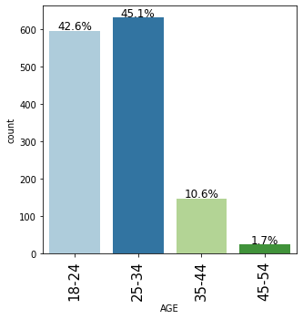

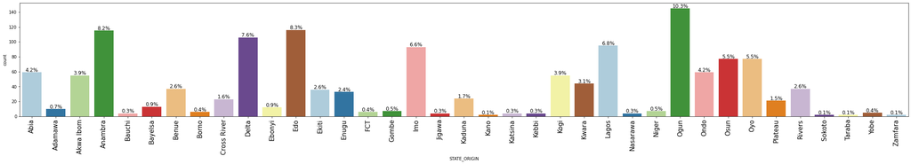

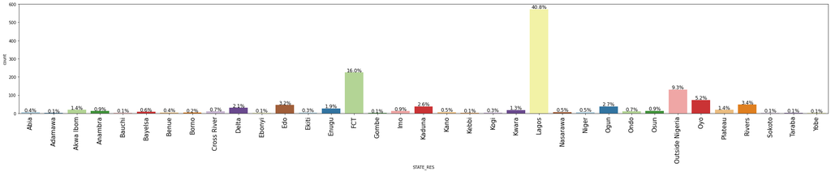

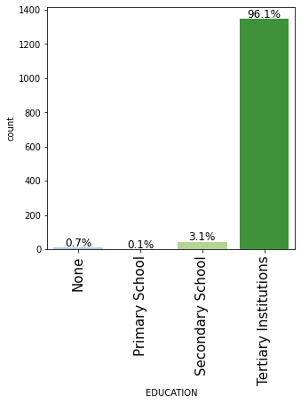

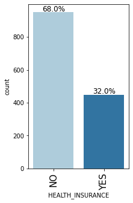

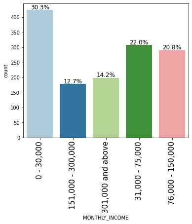

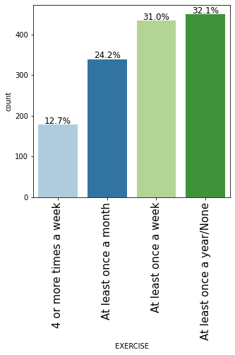

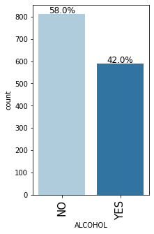

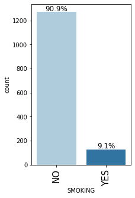

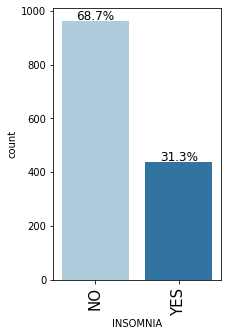

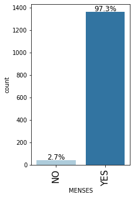

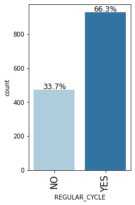

[12 more figures not shown]

```python
for feature in data1.columns:
    labeled_barplot(data1, feature, perc=True)
```

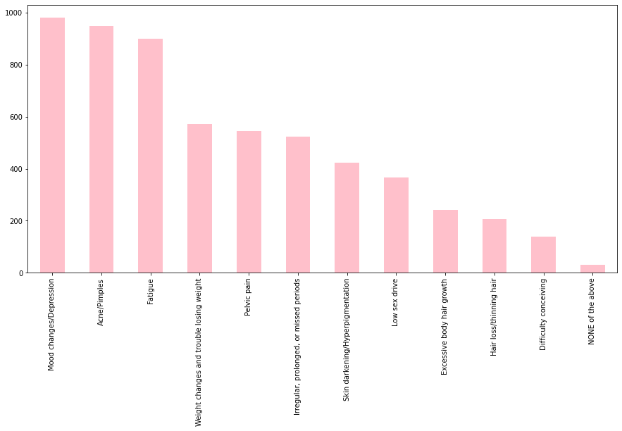

```python
# Visualizing frequency count of SYMPTOMS_1
Sy1.stack().value_counts().plot(kind="bar", figsize=(15, 7), color="pink")
plt.savefig("symp1-count.png", dpi=300, bbox_inches="tight")
```

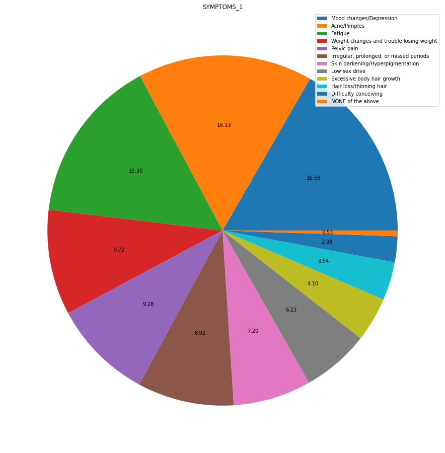

```python
# Visualizing frequency count of SYMPTOMS_1
Sy1.stack().value_counts().plot(
    kind="pie",
    autopct="%.2f",
    title="SYMPTOMS_1",
    labels=None,
    legend=True,
    figsize=(18, 16),
)
plt.ylabel("")
plt.savefig("symp1-countpie.png", dpi=300, bbox_inches="tight")
```

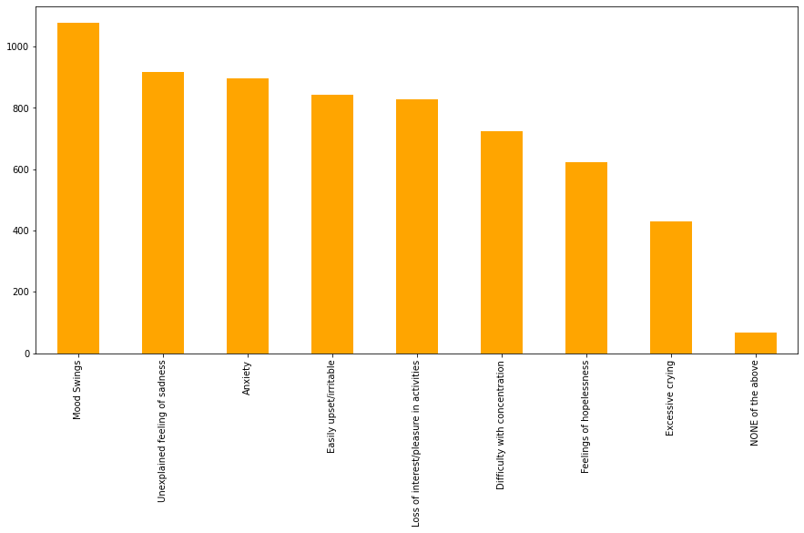

```python
# Visualizing frequency count of SYMPTOMS_2
Sy2.stack().value_counts().plot(kind="bar", figsize=(15, 7), color="orange")
plt.savefig("symp2-count.png", dpi=300, bbox_inches="tight")
```

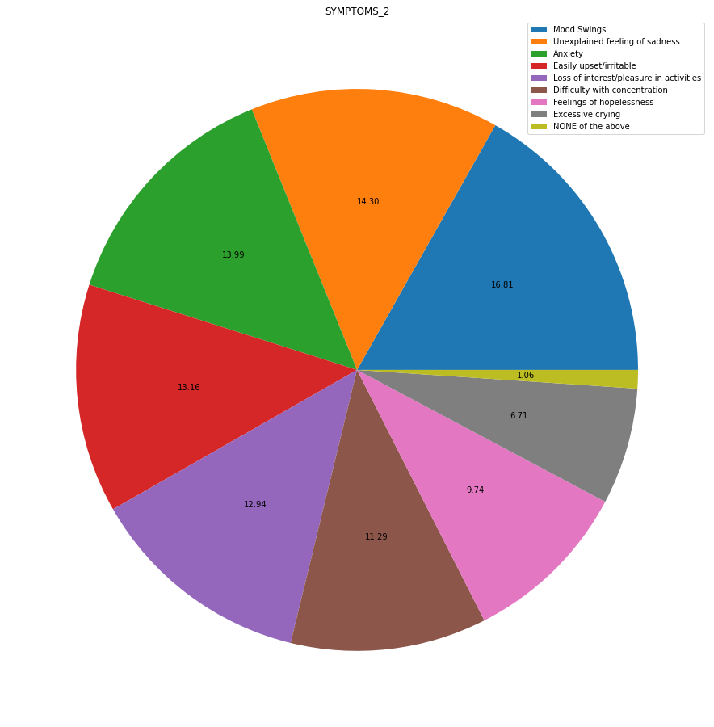

```python
# Visualizing frequency count of SYMPTOMS_2
Sy2.stack().value_counts().plot(
    kind="pie",
    autopct="%.2f",
    title="SYMPTOMS_2",
    legend="upper right",
    labels=None,
    figsize=(18, 16),
)
plt.ylabel("")
plt.savefig("symp2-countpie.png", dpi=300, bbox_inches="tight")
```

### Bivariate/Multivariate Analysis:

```python
### Function to plot stacked bar charts for categorical columns
def stacked_plot(x):
    sns.set()
    ## crosstab
    tab1 = pd.crosstab(x, data1["TREATMENT"], margins=True).sort_values(
        by="YES", ascending=False
    )
    print(tab1)
    print("-" * 120)
    ## visualising the cross tab
    tab = pd.crosstab(x, data1["TREATMENT"], normalize="index").sort_values(
        by="YES", ascending=False
    )
    tab.plot(kind="bar", stacked=True, figsize=(17, 7))
    plt.legend(
        loc="lower left",
        frameon=False,
    )
    plt.legend(loc="upper left", bbox_to_anchor=(1, 1))
    plt.show()
```

```python
def stacked_barplot(data, predictor, target):
    """
    Print the category counts and plot a stacked bar chart

    data: dataframe
    predictor: independent variable
    target: target variable
    """
    count = data[predictor].nunique()
    sorter = data[target].value_counts().index[-1]
    tab1 = pd.crosstab(data[predictor], data[target], margins=True).sort_values(
        by=sorter, ascending=False
    )
    print(tab1)
    print("-" * 120)
    tab = pd.crosstab(data[predictor], data[target], normalize="index").sort_values(
        by=sorter, ascending=False
    )
    fig = tab.plot(kind="bar", stacked=True, figsize=(count + 5, 5))
    plt.legend(
        loc="lower left",
        frameon=False,
    )
    plt.legend(loc="upper left", bbox_to_anchor=(1, 1))
    plt.show()

    return fig
```

### Observations on AGE vs. TREATMENT:

```
TREATMENT    NO  YES   All
AGE
All        1128  273  1401
25-34       490  142   632
18-24       505   92   597
35-44       115   33   148
45-54        18    6    24
------------------------------------------------------------------------------------------------------------------------
```

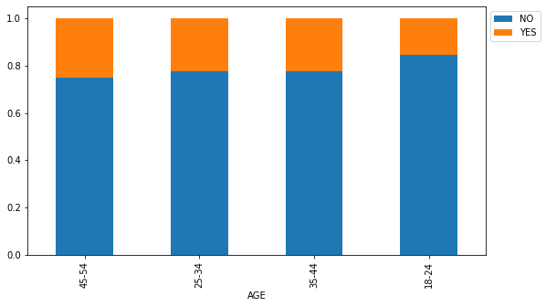

```python
fig = stacked_barplot(data1, "AGE", "TREATMENT")
#fig.figure.savefig("age-treatment.png", dpi=300, bbox_inches="tight")
```

### Observations on AGE vs. MONTHLY_INCOME:

```
MONTHLY_INCOME  0 - 30,000  151,000 - 300,000  301,000 and above  \
AGE
All                    425                178                199
25-34                  101                111                103
35-44                   14                 35                 53
18-24                  307                 27                 35
45-54                    3                  5                  8

MONTHLY_INCOME  31,000 - 75,000  76,000 - 150,000   All
AGE
All                         308               291  1401
25-34                       145               172   632
35-44                        12                34   148
18-24                       150                78   597
45-54                         1                 7    24
------------------------------------------------------------------------------------------------------------------------
```

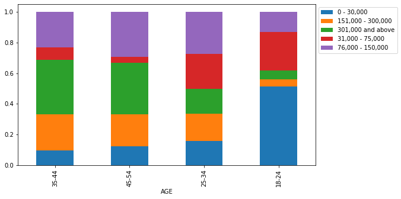

```python
fig = stacked_barplot(data1, "AGE", "MONTHLY_INCOME")
# fig.figure.savefig("age-income.png", dpi=300, bbox_inches="tight")
```

A majority of respondents fall within the lower income brackets.

### Observations on AGE vs. HEALTH_INSURANCE:

```
HEALTH_INSURANCE   NO  YES   All
AGE
All               952  449  1401
25-34             394  238   632
18-24             473  124   597
35-44              73   75   148
45-54              12   12    24
------------------------------------------------------------------------------------------------------------------------
```

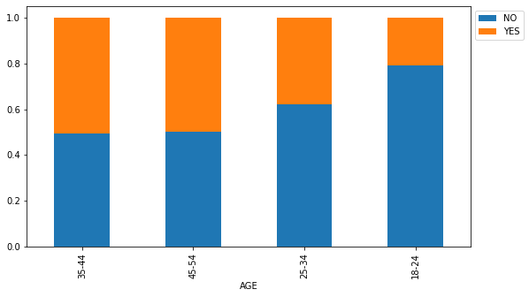

```python
fig = stacked_barplot(data1, "AGE", "HEALTH_INSURANCE")
# fig.figure.savefig("age-insurance.png", dpi=300, bbox_inches="tight")
```

Not surprisingly, more older respondents have health insurance.

### Observations on MONTHLY_INCOME vs. HEALTH_INSURANCE:

```
HEALTH_INSURANCE    NO  YES   All
MONTHLY_INCOME
All                952  449  1401
301,000 and above   48  151   199
76,000 - 150,000   186  105   291
151,000 - 300,000   81   97   178
31,000 - 75,000    254   54   308
0 - 30,000         383   42   425
------------------------------------------------------------------------------------------------------------------------
```

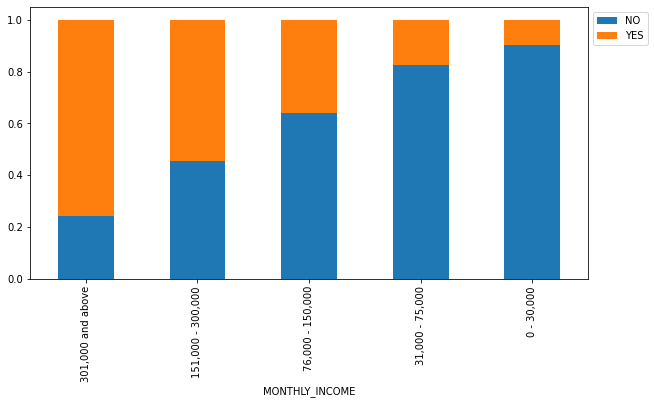

```python
fig = stacked_barplot(data1, "MONTHLY_INCOME", "HEALTH_INSURANCE")
# fig.figure.savefig("income-insurance", dpi=300, bbox_inches="tight")
```

Also not surprisingly, higher income groups have health insurance. This can be due to a combination of factors including better work conditions, age, access, etc.

### Observations on MONTHLY_INCOME vs. TREATMENT:

```
TREATMENT            NO  YES   All
MONTHLY_INCOME
All                1128  273  1401
301,000 and above   130   69   199
0 - 30,000          364   61   425
76,000 - 150,000    234   57   291
31,000 - 75,000     257   51   308
151,000 - 300,000   143   35   178
------------------------------------------------------------------------------------------------------------------------
```

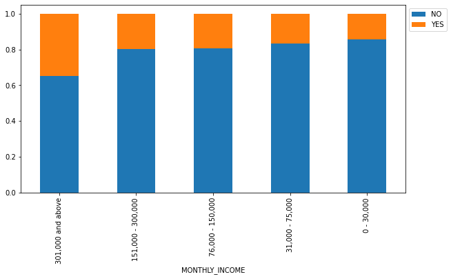

```python
fig = stacked_barplot(data1, "MONTHLY_INCOME", "TREATMENT")
# fig.figure.savefig("income-treatment.png", dpi=300, bbox_inches="tight")
```

Far fewer respondents seek treatment and the highest number of those seeking treatment are in the highest income group.

### Observations on HEALTH_INSURANCE vs. TREATMENT:

```
TREATMENT           NO  YES   All
HEALTH_INSURANCE
All               1128  273  1401
NO                 804  148   952
YES                324  125   449
------------------------------------------------------------------------------------------------------------------------
```

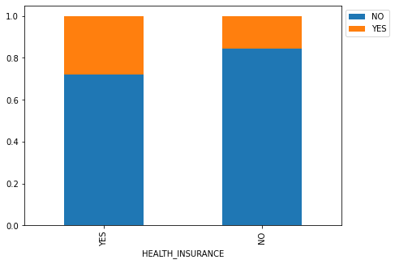

```python
fig = stacked_barplot(data1, "HEALTH_INSURANCE", "TREATMENT")
# fig.figure.savefig("insurance-treatment.png", dpi=300, bbox_inches="tight")
```

Again we see that having health insurance has a positive relationship to the number of people seeking treatment for PCOS.

### Observations on S1_GRP vs. TREATMENT:

```
TREATMENT    NO  YES   All
S1_GRP
All        1128  273  1401
4-7         562  168   730
0-3         519   60   579
8-11         47   45    92
------------------------------------------------------------------------------------------------------------------------
```

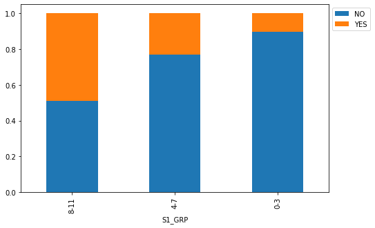

```python
fig = stacked_barplot(data1, "S1_GRP", "TREATMENT")
# fig.figure.savefig("symp1-treatment.png", dpi=300, bbox_inches="tight")
```

For SYMPTOMS_1, people with more symptoms have sought treatment and those with fewer symptoms sought treatment less.

### Observations on S2_GRP vs. TREATMENT:

```
TREATMENT    NO  YES   All
S2_GRP
All        1128  273  1401
6-8         451  121   572
3-5         370   86   456
0-2         307   66   373
------------------------------------------------------------------------------------------------------------------------
```

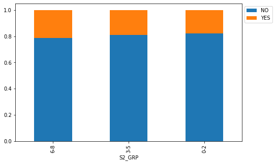

```python
fig = stacked_barplot(data1, "S2_GRP", "TREATMENT")
# fig.figure.savefig("symp2-treatment.png", dpi=300, bbox_inches="tight")
```

For SYMPTOMS_2, 21% of respondents with 6-8 symptoms sought treatment. Thsi is the highest ratio for this symptoms group.

### Observations on EDUCATION vs. TREATMENT:

```
TREATMENT                NO  YES   All
EDUCATION
All                    1128  273  1401
Tertiary Institutions  1080  267  1347
Secondary School         38    5    43
None                      9    1    10
Primary School            1    0     1
------------------------------------------------------------------------------------------------------------------------
```

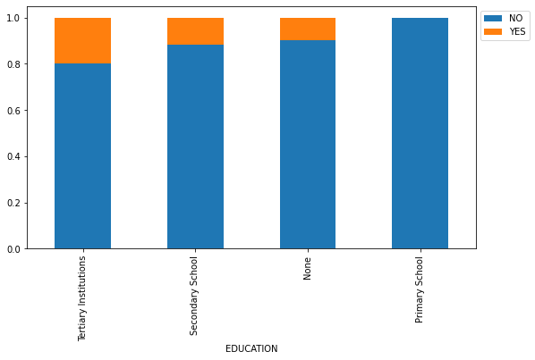

```python
fig = stacked_barplot(data1, "EDUCATION", "TREATMENT")
# fig.figure.savefig("education-treatment.png", dpi=300, bbox_inches="tight")
```

More respondents with tertiary education sought treatment. It appears that awareness and education plays a role in choosing to seek treatment.

### Observations on STATE_RES vs. TREATMENT:

```
TREATMENT          NO  YES   All
STATE_RES
All              1128  273  1401
Lagos             465  107   572
Outside Nigeria    84   46   130
FCT               189   35   224
Oyo                57   16    73
Edo                37    8    45
Rivers             41    7    48
Kaduna             31    6    37
Delta              25    5    30
Enugu              22    5    27
Plateau            15    4    19
Osun                9    4    13
Ondo                6    4    10
Ogun               34    4    38
Kwara              14    4    18
Abia                3    3     6
Imo                10    2    12
Anambra            10    2    12
Akwa Ibom          17    2    19
Kano                5    2     7
Kogi                3    1     4
Ebonyi              1    1     2
Niger               6    1     7
Cross River         9    1    10
Benue               4    1     5
Bayelsa             7    1     8
Borno               2    1     3
Ekiti               4    0     4
Nasarawa            7    0     7
Gombe               1    0     1
Bauchi              2    0     2
Kebbi               2    0     2
Adamawa             1    0     1
Sokoto              2    0     2
Taraba              2    0     2
Yobe                1    0     1
------------------------------------------------------------------------------------------------------------------------
```

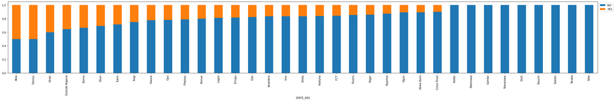

```python
fig = stacked_barplot(data1, "STATE_RES", "TREATMENT")
# fig.figure.savefig("statres-treatment.png", dpi=300, bbox_inches="tight")
```

### Observations on STATE_RES vs. EDUCATION:

```
EDUCATION        None  Primary School  Secondary School  \
STATE_RES
All                10               1                43
FCT                 3               1                 4
Kebbi               0               0                 0
Kwara               0               0                 0
Lagos               2               0                23
Nasarawa            0               0                 0
Niger               0               0                 0
Ogun                3               0                 2
Ondo                0               0                 0
Osun                0               0                 0
Outside Nigeria     0               0                 4
Oyo                 0               0                 2
Plateau             0               0                 0
Rivers              1               0                 1
Sokoto              0               0                 0
Taraba              0               0                 0
Yobe                0               0                 0
Kogi                0               0                 0
Abia                0               0                 0
Adamawa             0               0                 0
Cross River         0               0                 1
Akwa Ibom           0               0                 1
Anambra             0               0                 0
Bauchi              0               0                 0
Bayelsa             0               0                 0
Benue               0               0                 0
Borno               0               0                 0
Delta               0               0                 0
Kaduna              0               0                 0
Ebonyi              0               0                 0
Edo                 1               0                 4
Ekiti               0               0                 0
Enugu               0               0                 0
Gombe               0               0                 0
Imo                 0               0                 0
Kano                0               0                 1

EDUCATION        Tertiary Institutions   All
```

[output cut: 23 more lines]

```
Anambra                             12    12
Bauchi                               2     2
Bayelsa                              8     8
Benue                                5     5
Borno                                3     3
Delta                               30    30
Kaduna                              37    37
Ebonyi                               2     2
Edo                                 40    45
Ekiti                                4     4
Enugu                               27    27
Gombe                                1     1
Imo                                 12    12
Kano                                 6     7
------------------------------------------------------------------------------------------------------------------------
```

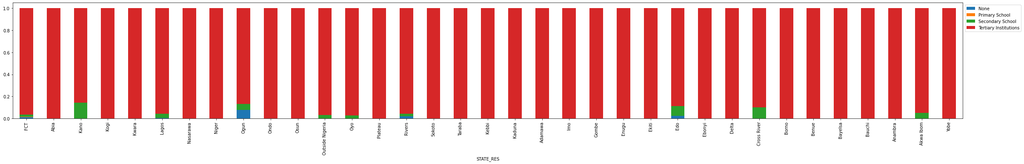

```python
fig = stacked_barplot(data1, "STATE_RES", "EDUCATION")
# fig.figure.savefig("statres-education.png", dpi=300, bbox_inches="tight")
```

Across board, most respondents have tertiary education and have noted that this group sought treatment more than any other. As such we can conclude that access to adequate medical facilities may be factor influencing the decision te seek treatment.

### Observations on AFFORDABILITY vs. TREATMENT:

```
AFFORDABILITY  1.0  2.0  3.0  4.0  5.0  No response   All
TREATMENT
All             92   80  109   36   23         1061  1401
YES             67   65   86   25   18           12   273
NO              25   15   23   11    5         1049  1128
------------------------------------------------------------------------------------------------------------------------
```

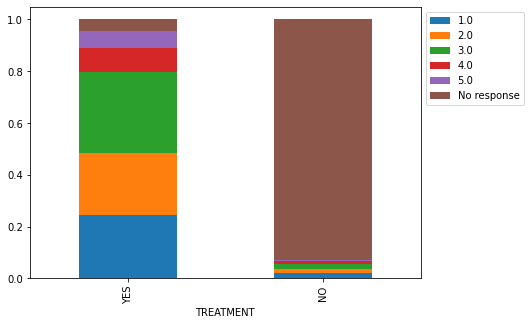

```python
fig = stacked_barplot(data1, "TREATMENT", "AFFORDABILITY")
# fig.figure.savefig("afford-treatment.png", dpi=300, bbox_inches="tight")
```

### Observations on AFFORDABILITY vs. INCOME:

```
MONTHLY_INCOME  0 - 30,000  151,000 - 300,000  301,000 and above  \
AFFORDABILITY
All                    425                178                199
No response            346                133                122
3.0                     23                 18                 20
1.0                     30                 11                 18
2.0                     16                  9                 18
4.0                      6                  6                  8
5.0                      4                  1                 13

MONTHLY_INCOME  31,000 - 75,000  76,000 - 150,000   All
AFFORDABILITY
All                         308               291  1401
No response                 238               222  1061
3.0                          22                26   109
1.0                          20                13    92
2.0                          19                18    80
4.0                           7                 9    36
5.0                           2                 3    23
------------------------------------------------------------------------------------------------------------------------
```

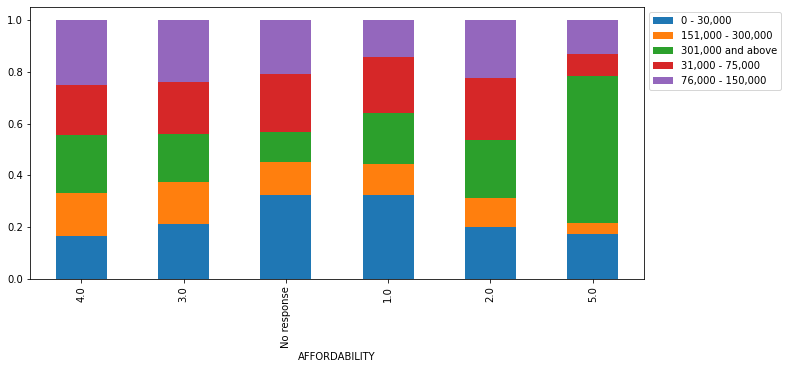

```python
fig = stacked_barplot(data1, "AFFORDABILITY", "MONTHLY_INCOME")
# fig.figure.savefig("afford-income.png", dpi=300, bbox_inches="tight")
```

Among those that sought treatment, highest number of respondents that found treatment to be affordable belong to the highest income group of 301,000 monthly and above. Conversely, the highest number to find treatment expensive are in the lowest income group.

### Observations on AGE vs. S1_GRP:

```
S1_GRP  0-3  4-7  8-11   All
AGE
All     579  730    92  1401
25-34   257  333    42   632
18-24   230  331    36   597
35-44    78   59    11   148
45-54    14    7     3    24
------------------------------------------------------------------------------------------------------------------------
```

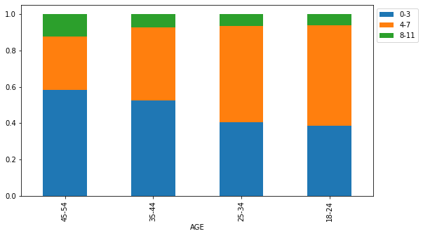

```python
fig = stacked_barplot(data1, "AGE", "S1_GRP")
# fig.figure.savefig("age-symp1.png", dpi=300, bbox_inches="tight")
```

Those with 8-11 symptoms sought treatment most and more fall within the 45-54 age group. Also notable is that the same age group has the highest number of those with 0-3 symptoms from SYMPTOMS_1.

### Observations on AGE vs. S2_GRP:

```
S2_GRP  0-2  3-5  6-8   All
AGE
All     373  456  572  1401
25-34   190  204  238   632
18-24    96  197  304   597
35-44    69   53   26   148
45-54    18    2    4    24
------------------------------------------------------------------------------------------------------------------------
```

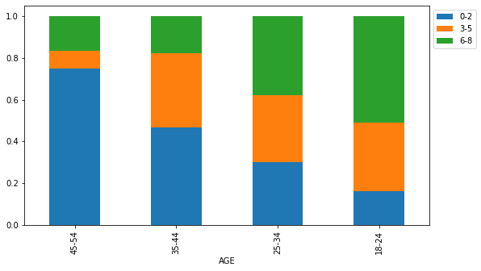

```python
fig = stacked_barplot(data1, "AGE", "S2_GRP")
# fig.figure.savefig("age-symp2.png", dpi=300, bbox_inches="tight")
```

Unlike SYMPTOMS_1, SYMPTOMS_2 shows a predominance of more symptoms among the lower age groups.